**City College of San Francisco**

MATH 108 - Foundations of Data Science

# Lecture 10: Groups

Associated Textbook Sections: [8.2, 8.3](https://inferentialthinking.com/chapters/08/2/Classifying_by_One_Variable.html)

## Set Up the Notebook

```python
from datascience import *
import numpy as np
%matplotlib inline
import matplotlib.pyplot as plots
plots.style.use('fivethirtyeight')
#import warnings
#warnings.simplefilter(action='ignore',category=np.VisibleDeprecationWarning)
```

## Sir Francis Galton

- 1822 - 1911 (knighted in 1909)
- Charles Darwin's half-cousin
- Developed systems for making predictions in several fields
- An advocate for eugenics and scientific racism

[figure not shown]

If you are not familiar with the concept of eugenics or scientific racism, you might consider watching the following TED-Ed video *The movement that inspired the Holocaust - Alexandra Minna Stern and Natalie Lira*.

**Keep in mind that the content in this video references forced reproductive sterilization and the Holocaust.**

```python
from IPython.display import IFrame

IFrame(src="https://www.youtube.com/embed/6zCpRVP1DgQ?rel=0&amp;controls=0&amp;showinfo=0", width="560", height="315")
```

[video not shown]

## Prediction

### Demo: Prediction

Load the Galton's data and visualize the relationship between `midparentHeight` and `childHeight`.

```python
galton = Table.read_table('data/galton.csv')
galton
```

| family | father | mother | midparentHeight | children | childNum | sex | childHeight |
| --- | --- | --- | --- | --- | --- | --- | --- |
| 1 | 78.5 | 67 | 75.43 | 4 | 1 | male | 73.2 |
| 1 | 78.5 | 67 | 75.43 | 4 | 2 | female | 69.2 |
| 1 | 78.5 | 67 | 75.43 | 4 | 3 | female | 69 |
| 1 | 78.5 | 67 | 75.43 | 4 | 4 | female | 69 |
| 2 | 75.5 | 66.5 | 73.66 | 4 | 1 | male | 73.5 |
| 2 | 75.5 | 66.5 | 73.66 | 4 | 2 | male | 72.5 |
| 2 | 75.5 | 66.5 | 73.66 | 4 | 3 | female | 65.5 |
| 2 | 75.5 | 66.5 | 73.66 | 4 | 4 | female | 65.5 |
| 3 | 75 | 64 | 72.06 | 2 | 1 | male | 71 |
| 3 | 75 | 64 | 72.06 | 2 | 2 | female | 68 |

... (924 rows omitted)

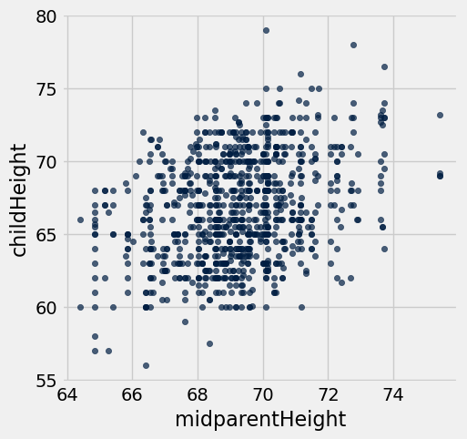

```python
galton.scatter('midparentHeight', 'childHeight')
```

Identify points that are within 0.5 of the `midparentHeight` value of 68.

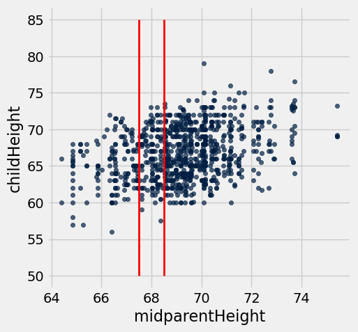

```python
galton.scatter('midparentHeight', 'childHeight')
plots.plot([67.5, 67.5], [50, 85], color='red', lw=2)
plots.plot([68.5, 68.5], [50, 85], color='red', lw=2);
```

```python
nearby = galton.where('midparentHeight', are.between(67.5, 68.5))
nearby_mean = nearby.column('childHeight').mean()
nearby_mean
```

```
66.24045801526718
```

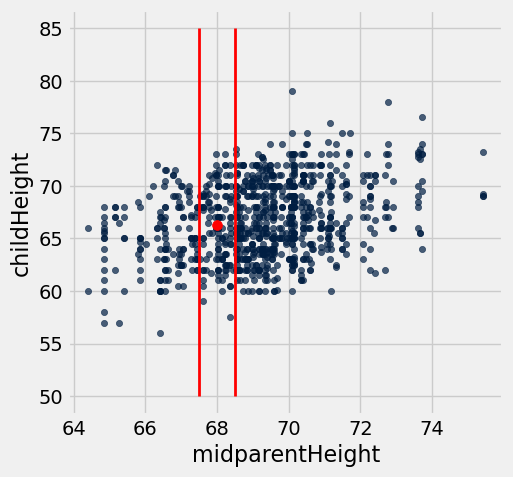

```python
galton.scatter('midparentHeight', 'childHeight')
plots.plot([67.5, 67.5], [50, 85], color='red', lw=2)
plots.plot([68.5, 68.5], [50, 85], color='red', lw=2)
plots.scatter(68, nearby_mean, color='red', s=50);
```

Create a function to predict the height of a child based on the average `childHeight` associated with the points within 0.5 of the given child's `midparentHeight` value.

```python
def predict(h):
    nearby = galton.where('midparentHeight', are.between(h - 0.5, h + 0.5))
    return nearby.column('childHeight').mean()
```

```python
predict(68)
```

```
66.24045801526718
```

```python
predict(70)
```

```
67.272850678733022
```

```python
predict(40) # no data, no prediction ...
```

```
nan
```

Apply the function to the `galton` table.

```python
predicted_heights = galton.apply(predict, 'midparentHeight')
galton = galton.with_column('predictedHeight', predicted_heights)
galton
```

| family | father | mother | midparentHeight | children | childNum | sex | childHeight | predictedHeight |
| --- | --- | --- | --- | --- | --- | --- | --- | --- |
| 1 | 78.5 | 67 | 75.43 | 4 | 1 | male | 73.2 | 70.1 |
| 1 | 78.5 | 67 | 75.43 | 4 | 2 | female | 69.2 | 70.1 |
| 1 | 78.5 | 67 | 75.43 | 4 | 3 | female | 69 | 70.1 |
| 1 | 78.5 | 67 | 75.43 | 4 | 4 | female | 69 | 70.1 |
| 2 | 75.5 | 66.5 | 73.66 | 4 | 1 | male | 73.5 | 70.4158 |
| 2 | 75.5 | 66.5 | 73.66 | 4 | 2 | male | 72.5 | 70.4158 |
| 2 | 75.5 | 66.5 | 73.66 | 4 | 3 | female | 65.5 | 70.4158 |
| 2 | 75.5 | 66.5 | 73.66 | 4 | 4 | female | 65.5 | 70.4158 |
| 3 | 75 | 64 | 72.06 | 2 | 1 | male | 71 | 68.5025 |
| 3 | 75 | 64 | 72.06 | 2 | 2 | female | 68 | 68.5025 |

... (924 rows omitted)

Visualize the predictions.

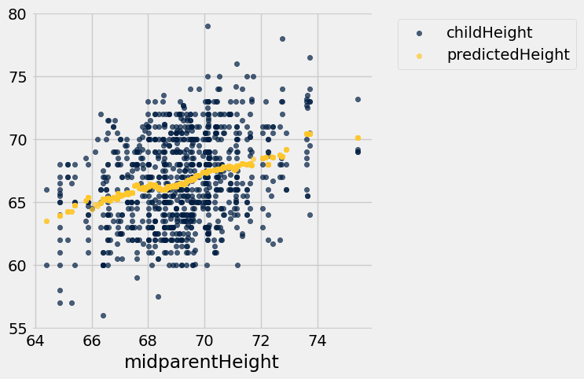

```python
(galton.select('midparentHeight', 'childHeight', 'predictedHeight')
       .scatter('midparentHeight'))
```

## Prediction Accuracy

### Demo: Prediction Accuracy

Define a function to compute the difference `x - y` between two values `x` and `y`.

```python
def difference(x, y):
    return x - y
```

Apply the function to the `galton` table to measure the difference between the `predictedHeight` and `childHeight` values. Add the results to the table.

```python
errors = galton.apply(difference, 'childHeight', 'predictedHeight')
galton = galton.with_column('errors', errors)
galton
```

| family | father | mother | midparentHeight | children | childNum | sex | childHeight | predictedHeight | errors |
| --- | --- | --- | --- | --- | --- | --- | --- | --- | --- |
| 1 | 78.5 | 67 | 75.43 | 4 | 1 | male | 73.2 | 70.1 | 3.1 |
| 1 | 78.5 | 67 | 75.43 | 4 | 2 | female | 69.2 | 70.1 | -0.9 |
| 1 | 78.5 | 67 | 75.43 | 4 | 3 | female | 69 | 70.1 | -1.1 |
| 1 | 78.5 | 67 | 75.43 | 4 | 4 | female | 69 | 70.1 | -1.1 |
| 2 | 75.5 | 66.5 | 73.66 | 4 | 1 | male | 73.5 | 70.4158 | 3.08421 |
| 2 | 75.5 | 66.5 | 73.66 | 4 | 2 | male | 72.5 | 70.4158 | 2.08421 |
| 2 | 75.5 | 66.5 | 73.66 | 4 | 3 | female | 65.5 | 70.4158 | -4.91579 |
| 2 | 75.5 | 66.5 | 73.66 | 4 | 4 | female | 65.5 | 70.4158 | -4.91579 |
| 3 | 75 | 64 | 72.06 | 2 | 1 | male | 71 | 68.5025 | 2.4975 |
| 3 | 75 | 64 | 72.06 | 2 | 2 | female | 68 | 68.5025 | -0.5025 |

... (924 rows omitted)

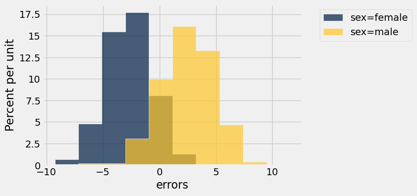

```python
galton.hist('errors', group='sex')
```

## Grouping

### Grouping by One Column

The group method aggregates all rows with the same value for a column into a single row in the resulting table.

- First argument: Which column to group by
- Second argument: (Optional) How to combine values
  - `len` — number of grouped values (default)
  - `list` — list of all grouped values
  - `sum` — total of all grouped values
  - ...

### Demo: Grouping by One Column

Load the `cones.csv` data and explore the `group` method.

```python
cones = Table.read_table('data/cones.csv')
cones
```

| Flavor | Color | Price |
| --- | --- | --- |
| strawberry | pink | 3.55 |
| chocolate | light brown | 4.75 |
| chocolate | dark brown | 5.25 |
| strawberry | pink | 5.25 |
| chocolate | dark brown | 5.25 |
| bubblegum | pink | 4.75 |

```python
cones.group('Flavor')
```

| Flavor | count |
| --- | --- |
| bubblegum | 1 |
| chocolate | 3 |
| strawberry | 2 |

```python
cones.drop('Color').group('Flavor', np.average)
```

| Flavor | Price average |
| --- | --- |
| bubblegum | 4.75 |
| chocolate | 5.08333 |
| strawberry | 4.4 |

```python
cones.drop('Color').group('Flavor', list)
```

| Flavor | Price list |
| --- | --- |
| bubblegum | [4.75] |
| chocolate | [4.75, 5.25, 5.25] |
| strawberry | [3.5499999999999998, 5.25] |

### Demo: Grouping By One Column: Welcome Survey

```python
survey = Table.read_table('data/welcome_survey_fa22.csv')
survey
```

| Section | Learning Objective | Pull Ups | DA Certificate | Born in US | Reaction Time | Work Hours per Week | Zipcode | Programming Experience | Top 3 Movie Genres | Personality | Top 2 Work Times | Data Science Work Goal | Top 2 Tutoring Days | Top 2 Tutoring Hours | Tutoring Environment | Sequence Length Memory | What approximate percentage of your life have you lived in San Francisco | COVID | Statistics Experience | Tatoos | Vision Support | Full Time Student | Course Preperation Feeling | Bachelor Degree | Registered to Vote | First Semester in College | Degree | Music Streaming | Recommend MATH 108 | … |
| --- | --- | --- | --- | --- | --- | --- | --- | --- | --- | --- | --- | --- | --- | --- | --- | --- | --- | --- | --- | --- | --- | --- | --- | --- | --- | --- | --- | --- | --- | --- |
| 70949 | 5 | 2 | 2 | nan | 300 | 15 | 94112 | 8 | Comedies, Romantic, Sci-fi & Fantasy | 2 | 6 pm - 10 pm, 10 pm - 2 am | 2 | Tuesday, Thursday | 6 am - 10 am, 6 pm - 10 pm | In person | 10 | 2 | 0 | 1 | 0 | 1 | 0 | 8 | 0 | Yes | 0 | Computer Science | Spotify | 1 | … |
| 70949 | 3 | 0 | 1 | 1 | 272 | 12 | 99999 | 1 | Anime, Comedies, Dramas | 1 | 10 am - 2 pm, 6 pm - 10 pm | 1 | Monday, Friday | 10 am - 2 pm, 2 pm - 6 pm | In person | 9 | 5 | 0 | 1 | 0 | 1 | 0 | 1 | 1 | Yes | 0 | Continuing Education | Spotify | 1 | … |
| 70949 | 3 | 1 | 0 | 0 | 257 | 2 | 99999 | 1 | Action & Adventure, Anime, Romantic | 1 | 10 am - 2 pm, 6 pm - 10 pm | 0 | Tuesday, Thursday | 10 am - 2 pm, 2 pm - 6 pm | Virtually | 14 | 5 | 999 | 4 | 0 | 1 | 1 | 4 | 0 | Yes | 0 | Psychology GRAD | YouTube Music | 1 | … |
| 70950 | 4 | 1 | 2 | 1 | 308 | 0 | 94115 | 2 | Documentaries, Dramas, Thrillers | 2 | 6 pm - 10 pm | 2 | Monday, Tuesday | 2 pm - 6 pm | In person | 9 | 2 | 0 | 4 | 0 | 1 | 1 | 3 | 1 | Yes | 0 | Continuing Education | Amazon Music | 1 | … |
| 70950 | 3 | 1 | 0 | 1 | 374 | 40 | 94103 | 2 | Comedies, Documentaries, Sci-fi & Fantasy | 2 | 10 am - 2 pm | 2 | Friday, Sunday | 6 pm - 10 pm | Virtually | 13 | 1 | 1 | 8 | 0 | 1 | 0 | 5 | 1 | Yes | 0 | Continuing Education | Spotify | 1 | … |
| 70949 | 4 | 2 | 0 | 1 | 290 | 40 | 94107 | 6 | Horror, Sci-fi & Fantasy, Thrillers | 2 | 6 am - 10 am, 6 pm - 10 pm | 1 | Tuesday, Thursday | I don't want tutoring support. | I don't want tutoring support | 9 | 2 | 3 | 6 | 0 | 0 | 1 | 10 | 1 | Yes | 0 | Continuing Education | Spotify | 1 | … |
| 70950 | 4 | 3 | 2 | 1 | 263 | 48 | 94110 | 1 | Action & Adventure, Documentaries, Sci-fi & Fantasy | 2 | 6 pm - 10 pm | 2 | Monday, Friday | 2 pm - 6 pm, 6 pm - 10 pm | Virtually | 7 | 1 | 1 | 4 | 0 | 1 | 0 | 3 | 1 | No | 1 | Computer Science | Spotify | 1 | … |
| 70949 | 4 | 2 | 2 | 0 | 250 | 45 | 94107 | 6 | Action & Adventure, Sci-fi & Fantasy, Thrillers | 2 | 2 pm - 6 pm, 6 pm - 10 pm | 1 | Monday, Wednesday | I don't want tutoring support. | I don't want tutoring support | 11 | 1 | 0 | 5 | 0 | 1 | 1 | 7 | 1 | Unknown | 0 | Computer Science | YouTube Music | 1 | … |
| 70950 | 3 | 6 | 0 | 1 | 319 | 40 | 94536 | 5 | Dramas, Sci-fi & Fantasy, Thrillers | 0 | 6 am - 10 am, 10 pm - 2 am | 2 | Thursday, Saturday | 2 pm - 6 pm | Virtually | 10 | 2 | 1 | 1 | 0 | 1 | 0 | 2 | 0 | Yes | 0 | Computer Networking and Information Technology | Spotify | 0 | … |
| 70950 | 3 | 25 | 1 | 0 | 225 | 60 | 94129 | 3 | Action & Adventure, Documentaries, Sci-fi & Fantasy | 1 | 10 pm - 2 am | 1 | Monday, Tuesday | 2 pm - 6 pm | Virtually | 9 | 1 | 0 | 7 | 1 | 1 | 0 | 7 | 0 | Ineligible | 0 | Business | Apple Music | 1 | … |

... (42 rows omitted)

## Lists

### Lists are Generic Sequences

- A list is a sequence of values (just like an array), but the values can all have different types:

  > `[2+3, 'four', Table().with_column('K', [3,4])]`
- Lists can be used to create table rows.
- If you create a table column from a list, it will be converted to an array automatically

### Demo: Lists

Demonstrate how to make a list.

```python
[5, 'dog', make_array(1,2,3), Table()]
```

```
[5, 'dog', array([1, 2, 3]), ]
```

### Grouping by Two Columns

The group method can also aggregate all rows that share the combination of values in multiple columns

- First argument: A list of which columns to group by
- Second argument: (Optional) How to combine values

### Demo: Grouping by Two Columns

Load the `welcome_survey_fa22.csv` data and group by more than one column.

```python
survey = Table.read_table('data/welcome_survey_fa22.csv')
survey
```

| Section | Learning Objective | Pull Ups | DA Certificate | Born in US | Reaction Time | Work Hours per Week | Zipcode | Programming Experience | Top 3 Movie Genres | Personality | Top 2 Work Times | Data Science Work Goal | Top 2 Tutoring Days | Top 2 Tutoring Hours | Tutoring Environment | Sequence Length Memory | What approximate percentage of your life have you lived in San Francisco | COVID | Statistics Experience | Tatoos | Vision Support | Full Time Student | Course Preperation Feeling | Bachelor Degree | Registered to Vote | First Semester in College | Degree | Music Streaming | Recommend MATH 108 | … |
| --- | --- | --- | --- | --- | --- | --- | --- | --- | --- | --- | --- | --- | --- | --- | --- | --- | --- | --- | --- | --- | --- | --- | --- | --- | --- | --- | --- | --- | --- | --- |
| 70949 | 5 | 2 | 2 | nan | 300 | 15 | 94112 | 8 | Comedies, Romantic, Sci-fi & Fantasy | 2 | 6 pm - 10 pm, 10 pm - 2 am | 2 | Tuesday, Thursday | 6 am - 10 am, 6 pm - 10 pm | In person | 10 | 2 | 0 | 1 | 0 | 1 | 0 | 8 | 0 | Yes | 0 | Computer Science | Spotify | 1 | … |
| 70949 | 3 | 0 | 1 | 1 | 272 | 12 | 99999 | 1 | Anime, Comedies, Dramas | 1 | 10 am - 2 pm, 6 pm - 10 pm | 1 | Monday, Friday | 10 am - 2 pm, 2 pm - 6 pm | In person | 9 | 5 | 0 | 1 | 0 | 1 | 0 | 1 | 1 | Yes | 0 | Continuing Education | Spotify | 1 | … |
| 70949 | 3 | 1 | 0 | 0 | 257 | 2 | 99999 | 1 | Action & Adventure, Anime, Romantic | 1 | 10 am - 2 pm, 6 pm - 10 pm | 0 | Tuesday, Thursday | 10 am - 2 pm, 2 pm - 6 pm | Virtually | 14 | 5 | 999 | 4 | 0 | 1 | 1 | 4 | 0 | Yes | 0 | Psychology GRAD | YouTube Music | 1 | … |
| 70950 | 4 | 1 | 2 | 1 | 308 | 0 | 94115 | 2 | Documentaries, Dramas, Thrillers | 2 | 6 pm - 10 pm | 2 | Monday, Tuesday | 2 pm - 6 pm | In person | 9 | 2 | 0 | 4 | 0 | 1 | 1 | 3 | 1 | Yes | 0 | Continuing Education | Amazon Music | 1 | … |
| 70950 | 3 | 1 | 0 | 1 | 374 | 40 | 94103 | 2 | Comedies, Documentaries, Sci-fi & Fantasy | 2 | 10 am - 2 pm | 2 | Friday, Sunday | 6 pm - 10 pm | Virtually | 13 | 1 | 1 | 8 | 0 | 1 | 0 | 5 | 1 | Yes | 0 | Continuing Education | Spotify | 1 | … |
| 70949 | 4 | 2 | 0 | 1 | 290 | 40 | 94107 | 6 | Horror, Sci-fi & Fantasy, Thrillers | 2 | 6 am - 10 am, 6 pm - 10 pm | 1 | Tuesday, Thursday | I don't want tutoring support. | I don't want tutoring support | 9 | 2 | 3 | 6 | 0 | 0 | 1 | 10 | 1 | Yes | 0 | Continuing Education | Spotify | 1 | … |
| 70950 | 4 | 3 | 2 | 1 | 263 | 48 | 94110 | 1 | Action & Adventure, Documentaries, Sci-fi & Fantasy | 2 | 6 pm - 10 pm | 2 | Monday, Friday | 2 pm - 6 pm, 6 pm - 10 pm | Virtually | 7 | 1 | 1 | 4 | 0 | 1 | 0 | 3 | 1 | No | 1 | Computer Science | Spotify | 1 | … |
| 70949 | 4 | 2 | 2 | 0 | 250 | 45 | 94107 | 6 | Action & Adventure, Sci-fi & Fantasy, Thrillers | 2 | 2 pm - 6 pm, 6 pm - 10 pm | 1 | Monday, Wednesday | I don't want tutoring support. | I don't want tutoring support | 11 | 1 | 0 | 5 | 0 | 1 | 1 | 7 | 1 | Unknown | 0 | Computer Science | YouTube Music | 1 | … |
| 70950 | 3 | 6 | 0 | 1 | 319 | 40 | 94536 | 5 | Dramas, Sci-fi & Fantasy, Thrillers | 0 | 6 am - 10 am, 10 pm - 2 am | 2 | Thursday, Saturday | 2 pm - 6 pm | Virtually | 10 | 2 | 1 | 1 | 0 | 1 | 0 | 2 | 0 | Yes | 0 | Computer Networking and Information Technology | Spotify | 0 | … |
| 70950 | 3 | 25 | 1 | 0 | 225 | 60 | 94129 | 3 | Action & Adventure, Documentaries, Sci-fi & Fantasy | 1 | 10 pm - 2 am | 1 | Monday, Tuesday | 2 pm - 6 pm | Virtually | 9 | 1 | 0 | 7 | 1 | 1 | 0 | 7 | 0 | Ineligible | 0 | Business | Apple Music | 1 | … |

... (42 rows omitted)

```python
survey.group(['Section', 'Tutoring Environment'])
```

| Section | Tutoring Environment | count |
| --- | --- | --- |
| 70949 | I don't want tutoring support | 5 |
| 70949 | In person | 19 |
| 70949 | Virtually | 7 |
| 70950 | I don't want tutoring support | 2 |
| 70950 | In person | 6 |
| 70950 | Virtually | 13 |

## Pivot Tables

### Pivot

- Cross-classifies according to two categorical variables
- Produces a grid of counts or aggregated values
- Two required arguments:
  - First: variable that forms column labels of grid
  - Second: variable that forms row labels of grid
- Two optional arguments (include both or neither)
  - `values=’column_label_to_aggregate’`
  - `collect=function_to_aggregate_with`

### Demo: Pivot Tables

Create pivot tables using the `survey` table.

```python
survey.pivot('Section', 'Tutoring Environment')
```

| Tutoring Environment | 70949 | 70950 |
| --- | --- | --- |
| I don't want tutoring support | 5 | 2 |
| In person | 19 | 6 |
| Virtually | 7 | 13 |

```python
(survey.where('Age', are.not_equal_to(999))
       .pivot('Section', 'Tutoring Environment', 'Age', np.average))
```

| Tutoring Environment | 70949 | 70950 |
| --- | --- | --- |
| I don't want tutoring support | 27.6667 | 41 |
| In person | 32.2105 | 31.8333 |
| Virtually | 22 | 27.9091 |